# Chapitre II. Tests paramétriques à un échantillon

2eme-FA-EMS - BUT SD - E. Anakok

# 1 Introduction

## 1.1 Tests paramétriques à un échantillon.

**WarningObjectif**

À partir d’un échantillon, comparer la caractéristique d’une population à une valeur de référence connue à priori :

1. **Test de comformité d’une moyenne**
2. **Test de comformité d’une proportion**
3. **Test de comformité d’une variance**

# 2 1. Test de conformité d’une moyenne

## 2.1 Ce qu’il faut retenir de ce cours 1/3

**Note1 - Modélisation**

On considère $(x_1,\dots,x_n)$ comme la réalisation d’un $n$-échantillon $(X_1,\dots,X_n)$ de v.a. i.i.d. de même loi que $X$ avec $\mathbb{E}[X] = \mu$, et $\mathbb{V}[X] = \sigma^2$

**Note2 - Test unilatéral à gauche**

$$H_0 : \mu = \mu_0$$
$$H_1 : \mu < \mu_0$$

**Note2 - Test bilatéral**

$$H_0 : \mu = \mu_0$$
$$H_1 : \mu \neq \mu_0$$

**Note2 - Test Unilatéral à droite**

$$H_0 : \mu = \mu_0$$
$$H_1 : \mu > \mu_0$$

**Note3 - Statistiques de test et loi sous $H_0$**

|  | Statistique de test | Loi de $T_n$ sous $H_0$ |  |
| --- | --- | --- | --- |
|  |  | Échantillon gaussien, $n$ petit | Grand échantillon, TCL |
| $\sigma^2$ connue | $T_n = \sqrt{n}\frac{(\bar{X}_n - \mu)}{\sigma}$ | $T_n \sim \mathcal{N}(0,1)$ | $T_n\xrightarrow[n\rightarrow\infty]{\mathscr{L}}\mathcal{N}(0,1)$ |
| $\sigma^2$ inconnue | $T_n = \sqrt{n}\frac{(\bar{X}_n - \mu)}{\textcolor{red}{S}}$ | $T_n \sim \mathcal{T}_{n-1}$ | $T_n\xrightarrow[n\rightarrow\infty]{\mathscr{L}}\mathcal{N}(0,1)$ |

## 2.2 Ce qu’il faut retenir de ce cours 2/3

**Note4 - Zone de rejet à gauche**

$$\{T_n< q_\alpha\}$$

**Note4 - Zone de rejet bilatéral**

$$\{|T_n|> q_{1-\frac{\alpha}{2}} \}$$

**Note4 - Zone de rejet à droite**

$$\{T_n> q_{1-\alpha}\}$$

**Note5 - Application numérique**

**Note6 - $p$-valeur (unilatéral gauche)**

$$p_c=\mathbb{P}_{H_0}(T_n<t_n)$$

**Note6 - $p$-valeur (bilatéral)**

$$p_c=\mathbb{P}_{H_0}(|T_n|>|t_n|)$$

**Note6 - $p$-valeur (unilatéral droite)**

$$p_c=\mathbb{P}_{H_0}(T_n>t_n)$$

## 2.3 Ce qu’il faut retenir de ce cours 3/3

**NoteTest unilatéral gauche**

```r
t.test(x, mu = mu0,
       alternative = "less")
```

**NoteTest bilateral**

```r
t.test(x, mu = mu0,
       alternative = "two.sided")
```

**NoteTest unilateral droite**

```r
t.test(x, mu = mu0,
       alternative = "greater")
```

**Note7 - Calcul de la puissance**

$$\beta = \mathbb{P}_{H_1}(\text{accepter }H_0),\quad \pi = 1 - \beta$$

**NoteEstimer la puissance statistique pour $n$ et $\alpha$ fixé :**

```r
power.t.test(n=9,
             delta=0.1,
             sd=sd(x),
             sig.level=0.05,
             type="one.sample",
             alternative="one.sided")
```

**NoteEstimer la taille d’échantillon $n$ pour avoir une puissance donnée**

```r
power.t.test(power=0.8,
             delta=0.1,
             sd=sd(x),
             sig.level=0.05,
             type="one.sample",
             alternative="one.sided")
```

## 2.4 Exemple 1 : la salmonelle

Plusieurs personnes ont souffert d’intoxication alimentaire de salmonelle. Après enquête, on suspecte une marque de glaces d’être responsable de l’intoxication. Pour vérifier cela, des scientifiques ont mesuré le niveau de salmonelle dans 9 pots de glace, tirés de façon aléatoire chez le fabricant de glace. On obtient les mesures suivantes, exprimées en NPP (Nombre le Plus Probable) par gramme :

```r
x<- c(0.175, 0.205, 0.760, 0.719, 0.199, 0.529, 0.306, 0.520, 0.010)
```

- On sait que le niveau de référence que doit respecter un fabricant de glaces est de 0.3 NPP/g.
- La question que l’on se pose est : le niveau moyen de salmonelle dans les pots de glace est-il supérieur à 0.3 ?

```r
mean(x)
```

```
[1] 0.3803333
```

## 2.5 Objectif

**WarningObjectif**

- Faire un test de niveau $\alpha$ sur la valeur de $\mu$ : la variable quantitative $X$ a-t-elle une moyenne $\mu$ égale à une valeur $\mu_0$ connue, donnée à l’avance ?
- À partir de l’échantillon, juger de la pertinence de l’hypothèse

$$H_0 : \mu = \mu_0$$
où $\mu_0$ est la moyenne théorique, en contrôlant le risque $\alpha$ de se tromper en rejetant $H_0$.

**CautionRemarques**

- On appelle ce type de test un test de conformité de moyenne, ou un test sur la valeur d’une espérance.
- On va comparer la moyenne empirique observée $\bar{x}_n$ et $\mu_0$.
- Distinguer :
  - un faible écart dû aux fluctuations d’échantillonnage
  - un écart significatif, peu probable par des fluctuations de l’estimateur.

## 2.6 1. Modélisation

**NoteModélisation**

On s’intéresse à un caractère quantitatif sur une population représenté par une v.a. $X$.

- Espérance : $\mathbb{E}[X] = \mu$, variance : $\mathbb{V}[X] = \sigma^2$
- On considère $(x_1,\dots,x_n)$ comme la réalisation d’un $n$-échantillon $(X_1,\dots,X_n)$ de v.a. i.i.d. de même loi que $X$.
- On note $\bar{X}_n=\frac{1}{n}\sum\limits_{i=1}^{n}X_i$ la moyenne empirique. Il s’agit d’une v.a., et sa réalisation est $\bar{x}_n=\frac{1}{n}\sum\limits_{i=1}^{n}x_i$
- $\bar{X}_n$ est un estimateur de $\mu$ et $\bar{x}_n$ est une estimation de $\mu$.

## 2.7 2. Hypothèse

De manière générale, on a trois alternatives possibles à l’hypothèse $H_0 : \mu = \mu_0$

**NoteDéfinition : **Test unilatéral à gauche**

Dans un test **test unilatéral à gauche**, l’hypothèse alternative est :

$$H_1 : \mu < \mu_0$$

**NoteDéfinition : **Test bilatéral**

Dans un test **test bilatéral**, l’hypothèse alternative est :

$$H_1 : \mu \neq \mu_0$$

**NoteDéfinition : **Test unilatéral à droite**

Dans un test **Test unilatéral à droite**, l’hypothèse alternative est :

$$H_1 : \mu > \mu_0$$

## 2.8 2. Hypothèse composites

**NoteDéfinition**

Les hypothèses **composites** (par opposition à l’hypothèse **simple**) sont définies par:

$$H_0: \mu\leq \mu_0 \quad \text{contre}\quad H_1: \mu>\mu_0$$
ou par

$$H_0: \mu\geq \mu_0 \quad \text{contre}\quad H_1: \mu<\mu_0$$

**CautionRemarques**

- $\mu$ peut prendre une multitude de valeurs sous l’hypothèse nulle, ceci risque de compliquer les calculs.

**TipSolution**

- $\alpha$ correspond au risque maximum que l’on accepte de prendre en rejetant $H_0$ à tort.
- Démarche : valeur de $\mu$ qui correspond au risque le plus élevé sous $H_0 \Rightarrow \mu = \mu_0$ .

$$\alpha = \sup_{\mu\in H_0} \alpha_\mu.$$

## 2.9 3. Statistique de test

Deux cas possibles :

**NoteStatistique de test avec variance connue**

Si $\sigma^2$ est connue :

$$T_n = \sqrt{n}\frac{(\bar{X}_n-\mu_0)}{\sigma}$$

**NoteStatistique de test avec variance inconnue**

Si $\sigma^2$ est inconnue,

$$T_n = \sqrt{n}\frac{(\bar{X}_n-\mu_0)}{S}$$

avec $S^2 = \frac{1}{n-1}\sum_{i=1}^{n}(X_i - \bar{X}_n)^2$ qui est un estimateur sans biais et consistant de $\sigma^2$.

**CautionRemarque**

Pour un test de conformité de moyenne, la statistique de test, $T_n$, est $\bar{X}_n$ centrée réduite sous $H_0$.

## 2.10 3. Loi de la statistique de test $T_n$ sous $H_0$

Deux cas :

- A-t-on un grand échantillon pour utiliser le théorème central limite (TCL)?
- Ou un petit échantillon de loi normale (gaussien) ?

## 2.11 Rappel: le Théorème central limite

**TipThéorème central limite**

Soit $(X_i)_{i\in\mathbb{N}}$ une suite de v.a. i.i.d. d’espérance $\mu_0$ et de variance $\sigma^2$ finies. Alors,

$$\sqrt{n} \frac{(\bar{X}_n - \mu_0)}{\sigma} \xrightarrow[n\rightarrow\infty]{\mathscr{L}}\mathcal{N}(0,1)$$

$$\sqrt{n} \frac{(\bar{X}_n - \mu_0)}{S} \xrightarrow[n\rightarrow\infty]{\mathscr{L}}\mathcal{N}(0,1)$$
avec $S^2 = \frac{1}{n-1}\sum_{i=1}^{n}(X_i - \bar{X}_n)^2$

**TipPour le test**

Lorsque l’échantillon sera grand, on pourra se servir du TCL sous l’hypothèse $H_0$ :
$$\mathbb{E}[X] =\mu = \mu_0$$

$$T_n = \sqrt{n}\frac{(\bar{X}_n-\mu_0)}{S} \xrightarrow[n\rightarrow\infty]{\mathscr{L}}\mathcal{N}(0,1)$$

## 2.12 3. Petit échantillon

Lorsque l’échantillon est petit $n\leq 30$ il faudra faire une hypothèse supplémentaire pour conclure.

**NoteHypothèse gaussienne**

En plus de la modélisation initiale, on suppose que
$$X_i \overset{i.i.d.}{\sim} \mathcal{N}(\mu,\sigma^2)$$

**TipLoi de la statistique de test $T_n$ sous $H_0$ et l’hypothèse gaussienne**

Sous $H_0$, si $X_i \overset{i.i.d.}{\sim} \mathcal{N}(\mu,\sigma^2)$, on a pour un échantillon de taille $n$

$$\text{Pour } \sigma \text{ connue : } T_n =\sqrt{n} \frac{(\bar{X}_n - \mu_0)}{\sigma} \sim\mathcal{N}(0,1)$$

$$\text{Pour } \sigma \text{ inconnue : } T_n = \sqrt{n} \frac{(\bar{X}_n - \mu_0)}{S} \sim \mathcal{T}(n-1)$$

## 2.13 3. Loi de la statistique de test $T_n$ sous $H_0$

|  | Statistique de test | Loi de $T_n$ sous $H_0$ |  |
| --- | --- | --- | --- |
|  |  | Échantillon gaussien, $n$ petit | Grand échantillon, TCL |
| $\sigma^2$ connue | $T_n = \sqrt{n}\frac{(\bar{X}_n - \mu)}{\sigma}$ | $T_n \sim \mathcal{N}(0,1)$ | $T_n\xrightarrow[n\rightarrow\infty]{\mathscr{L}}\mathcal{N}(0,1)$ |
| $\sigma^2$ inconnue | $T_n = \sqrt{n}\frac{(\bar{X}_n - \mu)}{\textcolor{red}{S}}$ | $T_n \sim \mathcal{T}_{n-1}$ | $T_n\xrightarrow[n\rightarrow\infty]{\mathscr{L}}\mathcal{N}(0,1)$ |

## 2.14 4. Constuire la zone de rejet

**WarningObjectif**

Contrôler le risque de première espèce pour un test de niveau $\alpha$.

**NoteDéfinition : Zone de rejet**

La zone de rejet, notée $R_\alpha$ est telle que
$$\mathbb{P}(\text{rejeter à tort }H_0) = \mathbb{P}_{H_0}(\text{rejeter }H_0) = \mathbb{P}_{H_0}(T_n\in R_\alpha)=\alpha$$

**NoteRappels**

1. Le quantile $\alpha \in [0,1]$ de la v.a. $T_n$ est le nombre réel $q_\alpha$ tel que

$$\mathbb{P}(T_n\leq q_\alpha ) = \alpha$$

2. Si deux variables aléatoires suivent la même loi, alors elles ont les mêmes quantiles.

**CautionRemarque**

- Si $T_n\sim\mathcal{N}(0,1)$ , alors $T_n$ a les mêmes quantiles que $\mathcal{N}(0,1)$
- Si $T_n\sim \mathcal{T}(n-1)$ , alors $T_n$ a les mêmes quantiles que $\mathcal{T}(n-1)$

## 2.15 4. Zone de rejet et règle de décision.

**CautionRemarques**

La zone de rejet va dépendre de $H_1$.

Unilatéral à gauche

Bilatéral

Unilatéral à droite

$H_1:$

$\mu<\mu_0$

$\mu\neq\mu_0$

$\mu>\mu_0$

Règle de décision, on rejette $H_0$ si…

$T_n$ est trop petit

$T_n$ est loin de 0

$T_n$ est trop grand

$R_\alpha$

$\{T_n< q_\alpha\}$

$\{|T_n|> q_{1-\frac{\alpha}{2}}\}$

$\{T_n> q_{1-\alpha}\}$

## 2.16 5. Mise en œuvre du test, A.N.

**TipApplication numérique**

Calcul de la réalisation $t_n$ de $T_n$ sur l’échantillon

- $\bar{x}_n= \frac{1}{n}\sum\limits_{i=1}^n x_i$ est la moyenne observée sur l’échantillon.
- si $\sigma^2$ est inconnue, $s^2 = \frac{1}{n-1}\sum_{i=1}^{n}(x_i - \bar{x}_n)^2$ est la variance observée sur l’échantillon; c’est l’estimation de $\sigma^2$ sur l’échantillon.
- si $\sigma^2$ est connue, $t_n = \sqrt{n}\frac{(\bar{x}_n-\mu_0)}{\sigma}$
- si $\sigma^2$ est inconnue, $t_n = \sqrt{n}\frac{(\bar{x}_n-\mu_0)}{s}$

**TipConclusion**

- Si $t_n\in R_\alpha$ : On rejette $H_0$, on accepte $H_1$.
- Si $t_n\notin R_\alpha$ : On conserve $H_0$.

## 2.17 Mise en œuvre du test : exemple

```r
xbar <- mean(x)
print(xbar)
```

```
[1] 0.3803333
```

```r
n <- length(x)
sigma = sqrt(var(x))
tn <- sqrt(n)*(xbar-0.3)/sigma
print(tn)
```

```
[1] 0.9200518
```

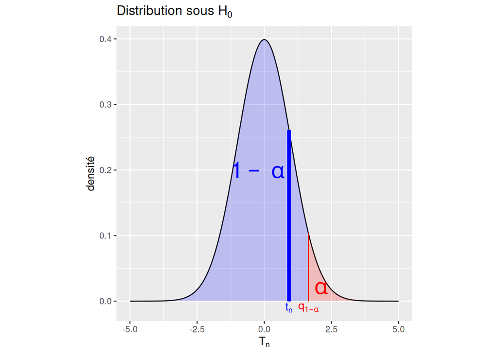

**Conclusion** : On ne rejette pas $H_0$. Le test n’est pas significatif au niveau $\alpha = 5\%$. Les données ne sont pas en contradiction avec $H_0$.

## 2.18 6. Probabilité critique, $p$-valeur

On a le résultat pour $\alpha=5\%$, mais que dire si $\alpha=10\%$ ? $\alpha=15\%$ ? $\alpha=20\%$ ?

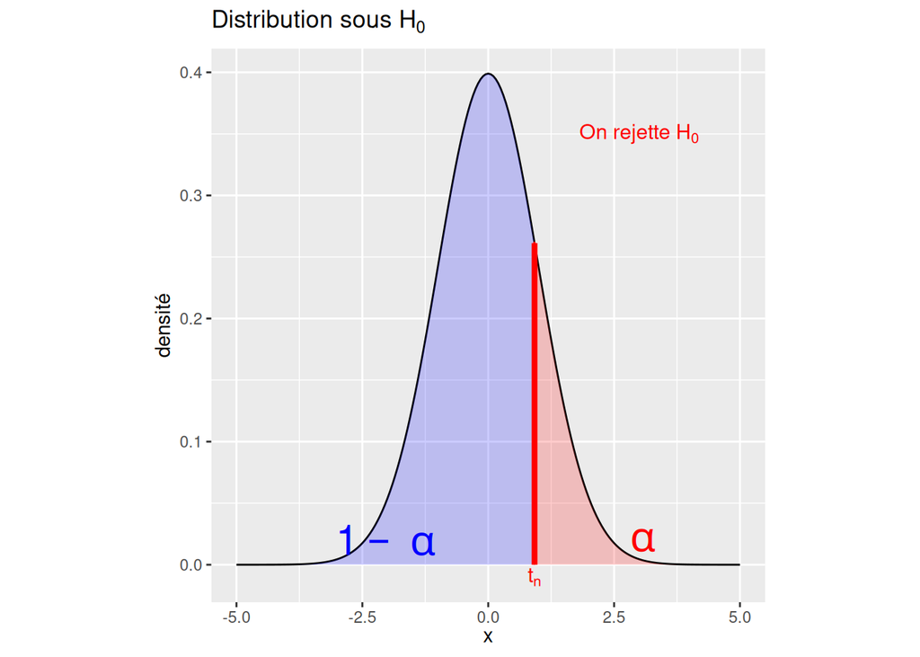

- $\textcolor{red}{p_c = \inf_\alpha\{t_n \in R_\alpha\}}$
- Ici, on a $p_c = \mathbb{P}_{H_0}(T_n > t_n)$

```r
1-pnorm(tn,0,1)
```

```
[1] 0.1787492
```

- Si $p_c < \alpha$, on rejette $H_0$ au niveau $\alpha$.
- Si $p_c>\alpha$, on ne rejette pas $H_0$ au niveau $\alpha$.

## 2.19 6. Calculer la $p$-valeur

**CautionRemarques**

$p_c$ va dépendre de $H_1$.

|  | Unilatéral à gauche | Bilatéral | Unilatéral à droite |
| --- | --- | --- | --- |
| $H_1:$ | $\mu<\mu_0$ | $\mu\neq\mu_0$ | $\mu>\mu_0$ |
| $p_c$ | $p_c=\mathbb{P}_{H_0}(T_n<t_n)$ | $p_c=\mathbb{P}_{H_0}(\|T_n\|>\|t_n\|)$ $= 2(1-\mathbb{P}_{H_0}(T_n \leq \|t_n\|))$ | $p_c=\mathbb{P}_{H_0}(T_n>t_n)$ $= 1-\mathbb{P}_{H_0}(T_n\leq t_n)$ |

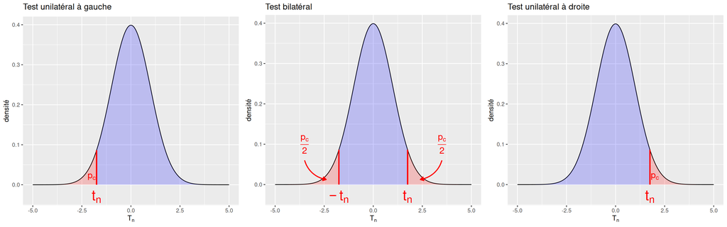

## 2.20 Applications sous R : t-test à 1 échantillon

- À partir d’un échantillon de mesures de $X$, noté $x= (x_1,\dots,x_n)$.

Test $H_0: \mu = \mu_0$ contre $H_1 : \mu < \mu_0$

```r
t.test(x, mu = mu0, alternative = "less")
```

Test $H_0: \mu = \mu_0$ contre $H_1 : \mu \neq \mu_0$

```r
t.test(x, mu = mu0)
```

Test $H_0: \mu = \mu_0$ contre $H_1 : \mu > \mu_0$

```r
t.test(x, mu = mu0, alternative = "greater")
```

## 2.21 Dans notre exemple

```r
t.test(x,mu = 0.3, alternative = "greater")
```

```
    One Sample t-test

data:  x
t = 0.92005, df = 8, p-value = 0.1922
alternative hypothesis: true mean is greater than 0.3
95 percent confidence interval:
 0.2179689       Inf
sample estimates:
mean of x
0.3803333
```

**CautionRemarques**

- Les logiciels renvoient $p_c$, c’est à nous de fixer $\alpha$.
- Dans un rapport, il faut toujours donner la valeur exacte de la $p_c$ et ne jamais donner des informations du type : “$p_c$> 5%” sans donner explicitement la $p_c$.

## 2.22 Applications sous R

Lorsque $n$ est grand, on utilise aussi *t.test*.

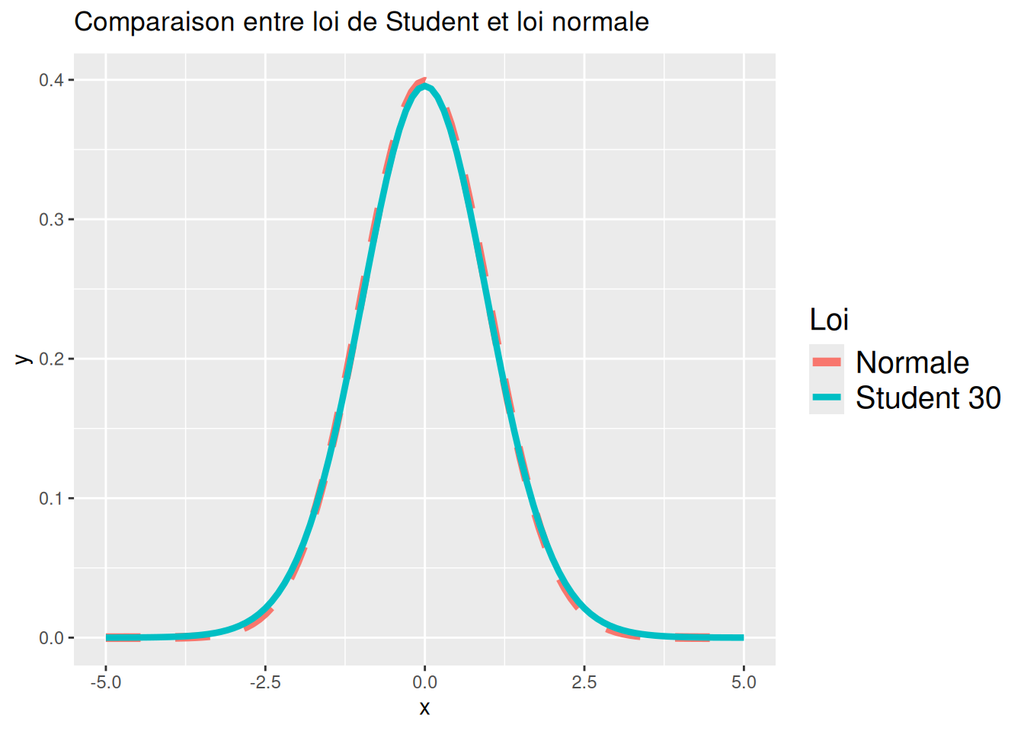

## 2.23 Exemple 2

Une entreprise produit des balles de ping-pong dont le diamètre moyen doit être égal à une norme de référence de 4cm. Pour savoir si la norme de qualité est respectée, un lot de 100 balles est prélevé sur lequel on observe

```r
length(diam)
```

```
[1] 100
```

```r
mean(diam)
```

```
[1] 4.010611
```

```r
sd(diam)
```

```
[1] 0.0238033
```

La norme est-elle respectée ?

## 2.24 Exemple 2

Test $H_0: \mu = \mu_0$ contre $H_1 : \mu \neq \mu_0$

```r
t.test(diam, mu = 4)
```

```
    One Sample t-test

data:  diam
t = 4.4579, df = 99, p-value = 2.185e-05
alternative hypothesis: true mean is not equal to 4
95 percent confidence interval:
 4.005888 4.015334
sample estimates:
mean of x
 4.010611
```

Calcul manuel avec l’approximation normale :

```r
tn = sqrt(length(diam))*(mean(diam)-4)/sd(diam)
tn
```

```
[1] 4.45792
```

```r
pvaleur = 2*(1-pnorm(abs(tn),0,1))
pvaleur
```

```
[1] 8.27586e-06
```

## 2.25 7. Risque de deuxième espèce et puissance

Les services sanitaires ont des raisons de croire que lorsque qu’un pot de glace est contaminé, la quantité de salmonelle dans le pot vaut en moyenne 0.4 NNP/g. On va alors tester

$$H_0 : \mu= 0.3 \quad\text{contre}\quad H_1: \mu= 0.4$$

**WarningObjectif**

Avec la procédure mise en place précédemment, peut-on déterminer $\beta$ le risque de deuxième espèce, et $\pi$ la puissance du test ?

## 2.26 7. Risque de deuxième espèce

**NoteRappel**

$$\beta = \mathbb{P}(\text{accepter à tort }H_0) = \mathbb{P}_{H_1}(\text{accepter }H_0)$$

## 2.27 Risque de deuxième espèce

Sous $H_1$, $X_i\overset{i.i.d}{\sim} \mathcal{N}(\mu,\sigma^2)$ d’où $X_i \overset{i.i.d}{\sim} \mathcal{N}(\textcolor{red}{0.4},\sigma^2), \quad \text{avec } \sigma^2 = 0.0686$

Sous $H_1$, on a $\bar{X}_n \sim \mathcal{N}\left(\mu,\frac{\sigma^2}{n}\right)=\mathcal{N}\left(\textcolor{red}{0.4},\frac{\sigma^2}{n}\right)$

$$T_n = \sqrt{n} \frac{(\bar{X}_n-0.3)}{\sigma}.$$

$\bar{X}_n \sim \mathcal{N}\left(\textcolor{red}{0.4},\frac{\sigma^2}{n}\right)$ $\Rightarrow (\bar{X}_n-0.3) \sim \mathcal{N}\left(\textcolor{red}{0.1},\frac{\sigma^2}{n}\right)$$\Rightarrow (\bar{X}_n-0.3)-\textcolor{red}{0.1} \sim \mathcal{N}\left(0 ,\frac{\sigma^2}{n}\right)$

$\Rightarrow \sqrt{n} \frac{(\bar{X}_n-0.3)}{\sigma} - \textcolor{red}{\sqrt{n} \frac{0.1}{\sigma}}\sim \mathcal{N}\left(0 ,1\right)$ $\Rightarrow T_n - \textcolor{red}{\sqrt{n} \frac{0.1}{\sigma}}\sim \mathcal{N}\left(0 ,1\right)$

## 2.28 7. Risque de deuxième espèce

```r
Alpha <- 0.05
q_1_alpha <- qnorm(1-Alpha)
rouge <- sqrt(n) * (0.4-0.3)/sigma
beta<-(pnorm(q_1_alpha  - rouge))
print(beta)
```

```
[1] 0.6912682
```

$$\beta = 0.691$$
$$\pi = 1-\beta = 0.309$$

## 2.29 7. Risques et puissance

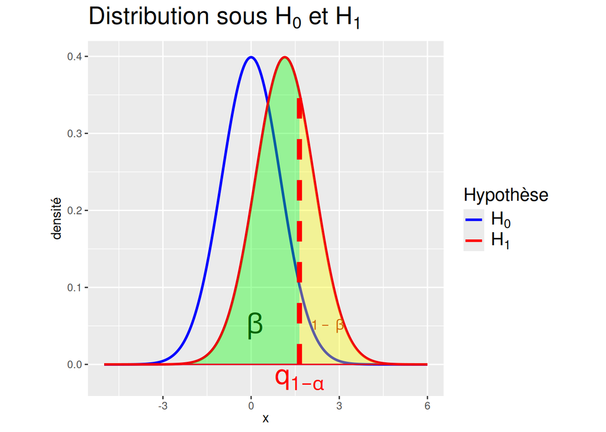

## 2.30 7. Risques et puissance

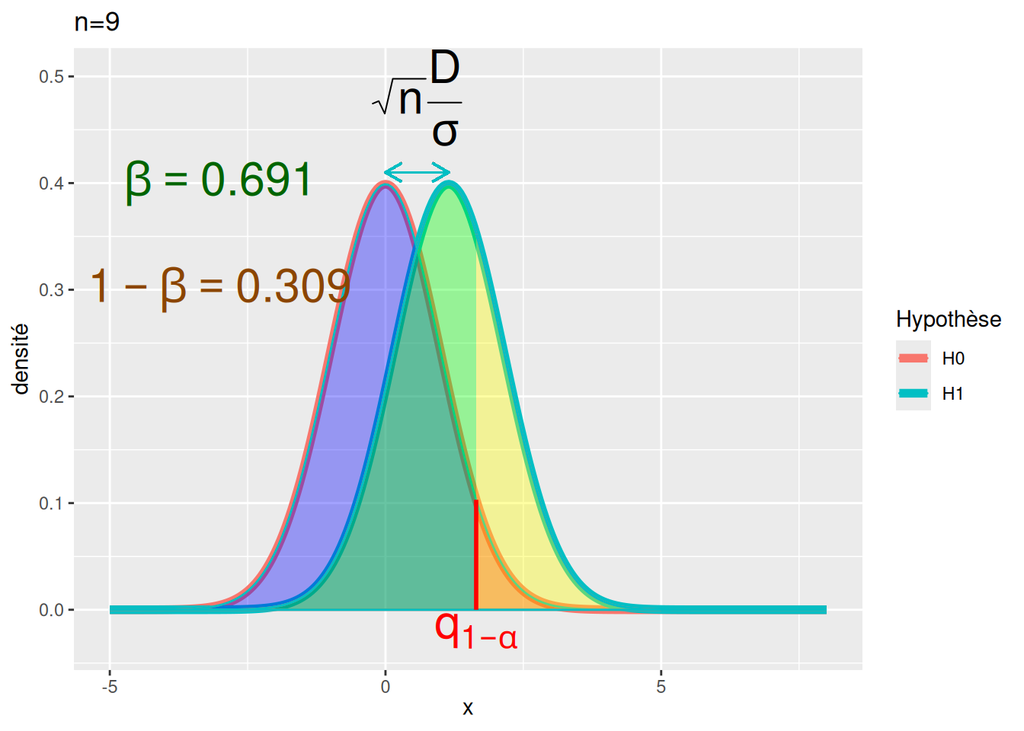

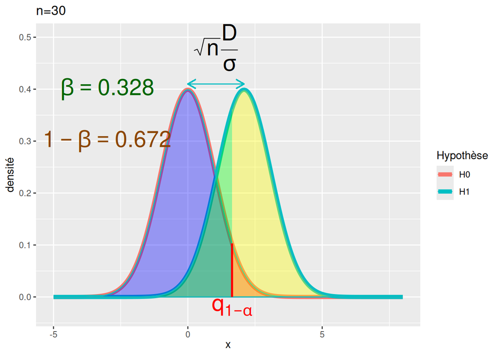

**TipPropriétés**

- Quand le niveau $\alpha$ augmente, le risque $\beta$ diminue, et la puissance $1-\beta$ augmente.
- Plus $H_1$ est loin de $H_0$, plus la puissance augmente.
- Quand le nombre d’observation augmente, la puissance augmente.
- Pour $\alpha = 5\%$, combien d’observations pour avoir une puissance de 80% ? 90% ?

## 2.31 Tests statistiques sur R

Estimer la puissance statistique pour $n$ et $\alpha$ fixé :

```r
power.t.test(n=9,
             delta=0.1,
             sd=sd(x),
             sig.level=0.05,
             type="one.sample",
             alternative="one.sided")
```

```
     One-sample t test power calculation

              n = 9
          delta = 0.1
             sd = 0.2619418
      sig.level = 0.05
          power = 0.2757187
    alternative = one.sided
```

```r
power.t.test(n=9,
             delta=0.2,
             sd=sd(x),
             sig.level=0.05,
             type="one.sample",
             alternative="one.sided")
```

```
     One-sample t test power calculation

              n = 9
          delta = 0.2
             sd = 0.2619418
      sig.level = 0.05
          power = 0.6723857
    alternative = one.sided
```

## 2.32 Tests statistiques sur R

Estimer le nombre d’observations nécessaires pour avoir une puissance donnée :

```r
power.t.test(power=0.8,
             delta=0.1,
             sd=sd(x),
             sig.level=0.05,
             type="one.sample",
             alternative="one.sided")
```

```
     One-sample t test power calculation

              n = 43.8057
          delta = 0.1
             sd = 0.2619418
      sig.level = 0.05
          power = 0.8
    alternative = one.sided
```

```r
power.t.test(power=0.9,
             delta=0.1,
             sd=sd(x),
             sig.level=0.05,
             type="one.sample",
             alternative="one.sided")
```

```
     One-sample t test power calculation

              n = 60.13851
          delta = 0.1
             sd = 0.2619418
      sig.level = 0.05
          power = 0.9
    alternative = one.sided
```

## 2.33 Ce qu’il faut retenir de ce cours 1/3

**Note1 - Modélisation**

On considère $(x_1,\dots,x_n)$ comme la réalisation d’un $n$-échantillon $(X_1,\dots,X_n)$ de v.a. i.i.d. de même loi que $X$ avec $\mathbb{E}[X] = \mu$, et $\mathbb{V}[X] = \sigma^2$

**Note2 - Test unilatéral à gauche**

$$H_0 : \mu = \mu_0$$
$$H_1 : \mu < \mu_0$$

**Note2 - Test bilatéral**

$$H_0 : \mu = \mu_0$$
$$H_1 : \mu \neq \mu_0$$

**Note2 - Test Unilatéral à droite**

$$H_0 : \mu = \mu_0$$
$$H_1 : \mu > \mu_0$$

**Note3 - Statistiques de test et loi sous $H_0$**

|  | Statistique de test | Loi de $T_n$ sous $H_0$ |  |
| --- | --- | --- | --- |
|  |  | Échantillon gaussien, $n$ petit | Grand échantillon, TCL |
| $\sigma^2$ connue | $T_n = \sqrt{n}\frac{(\bar{X}_n - \mu)}{\sigma}$ | $T_n \sim \mathcal{N}(0,1)$ | $T_n\xrightarrow[n\rightarrow\infty]{\mathscr{L}}\mathcal{N}(0,1)$ |
| $\sigma^2$ inconnue | $T_n = \sqrt{n}\frac{(\bar{X}_n - \mu)}{\textcolor{red}{S}}$ | $T_n \sim \mathcal{T}_{n-1}$ | $T_n\xrightarrow[n\rightarrow\infty]{\mathscr{L}}\mathcal{N}(0,1)$ |

## 2.34 Ce qu’il faut retenir de ce cours 2/3

**Note4 - Zone de rejet à gauche**

$$\{T_n< q_\alpha\}$$

**Note4 - Zone de rejet bilatéral**

$$\{|T_n|> q_{1-\frac{\alpha}{2}} \}$$

**Note4 - Zone de rejet à droite**

$$\{T_n> q_{1-\alpha}\}$$

**Note5 - Application numérique**

**Note6 - $p$-valeur (unilatéral gauche)**

$$p_c=\mathbb{P}_{H_0}(T_n<t_n)$$

**Note6 - $p$-valeur (bilatéral)**

$$p_c=\mathbb{P}_{H_0}(|T_n|>|t_n|)$$

**Note6 - $p$-valeur (unilatéral droite)**

$$p_c=\mathbb{P}_{H_0}(T_n>t_n)$$

## 2.35 Ce qu’il faut retenir de ce cours 3/3

**NoteTest unilatéral gauche**

```r
t.test(x, mu = mu0,
       alternative = "less")
```

**NoteTest bilateral**

```r
t.test(x, mu = mu0,
       alternative = "two.sided")
```

**NoteTest unilateral droite**

```r
t.test(x, mu = mu0,
       alternative = "greater")
```

**Note7 - Calcul de la puissance**

$$\beta = \mathbb{P}_{H_1}(\text{accepter }H_0),\quad \pi = 1 - \beta$$

**NoteEstimer la puissance statistique pour $n$ et $\alpha$ fixé :**

```r
power.t.test(n=9,
             delta=0.1,
             sd=sd(x),
             sig.level=0.05,
             type="one.sample",
             alternative="one.sided")
```

**NoteEstimer la taille d’échantillon $n$ pour avoir une puissance donnée**

```r
power.t.test(power=0.8,
             delta=0.1,
             sd=sd(x),
             sig.level=0.05,
             type="one.sample",
             alternative="one.sided")
```

# 3 2. Test de conformité sur la proportion

## 3.1 Ce qu’il faut retenir de ce cours

**Test de conformité d’une proportion**

**TipThéorème : lien avec le test de conformité de moyenne**

**Le test de conformité de proportion est un cas particulier du test de conformité de moyenne**

**Note1 - Modélisation**

$n$-échantillon i.i.d. $(X_1,\dots,X_n)$ de loi $\mathcal{B}(p)$

**Note2 - Hypothèses**

$$H_0 : p=p_0$$

**Tip3 - Statistique de test dans le cas grand échantillon**

$$T_n = \sqrt{n} \frac{(\bar{X}_n-p_0)}{\sqrt{p_0(1-p_0)}}\sim \mathcal{N}(0,1)$$

**Test de conformité d’une variance**

**Note1 - Modélisation**

$n$-échantillon i.i.d. $(X_1,\dots,X_n)$ de loi $\mathcal{N}(\mu,\sigma^2)$

**Note2 - Hypothèses**

$$H_0 : \sigma^2=\sigma^2_0$$

**Tip3 - Statistiques de test**

- $\mu$ est **connue** $S_e^2 = \frac{1}{n}\sum_{i=1}^n (X_i-\mu)^2, \quad T_n = \frac{nS_e^2}{\sigma_0^2} \sim\chi^2(n)$
- $\mu$ est **inconnue** $S^2 = \frac{1}{n-1}\sum_{i=1}^n (X_i-\bar{X}_n)^2,\quad T_n = \frac{(n-1)S^2}{\sigma_0^2} \sim\chi^2(n-1)$

**Tip4 - Zone de rejet dans le cas bilatéral**

$$R_\alpha = \left]0, \chi^2_{n-1, \frac{\alpha}{2} }\right[ \cup \left]\chi^2_{n-1,1- \frac{\alpha}{2}},+\infty \right[$$
La zone de rejet n’est pas symétrique.

## 3.2 Exemple

Un an avant les élections municipales, un maire d’un village de 300 habitants se demande quelles seront les intentions de vote aux prochaines élections. Il charge un élu du conseil municipal d’aller sonder un échantillon représentatif de la population de 50 habitants en leur demandant pour qui ils comptent voter. Aux dernières élections, ce maire avait obtenu 65% des votes.

- Les résultats font apparaître 70% d’intentions positives de vote en faveur du maire.
- Peut-on conclure que la côté de popularité du maire a évoluée ?

## 3.3 Objectif

**WarningObjectif**

La proportion $p$ d’individus possédant le caractère $X$ dans la population est-elle égale à une valeur $p_0$ connue, donnée à l’avance ?

- À partir d’un échantillon, juger de la pertinence de l’hypothèse

$$H_0 : p=p_0$$

où $p_0$ est la proportion théorique, en contrôlant le risque $\alpha$ de se tromper en rejetant $H_0$.

## 3.4 1. Modélisation

**Note1 - Modélisation**

- La variable $X$ est définie par :
  - $\{X = 1\}$ si l’individu possède la propriété en question
  - $\{X = 0\}$ sinon
- On suppose que $\mathbb{P}(X=1) = p$ et que $\mathbb{P}(X=0)=1-p$. On notera $X\sim \mathcal{B}(p)$
- $n$-échantillon $(X_1,\dots,X_n)$ de loi $\mathcal{B}(p)$
- On a $n$ observations $(x_1,\dots,x_n)$.

**NoteExemple**

- Proportion d’intentions de votes favorables à un candidat.
  - $\{X = 1\}$ si l’individu est favorable au candidat
  - $\{X = 0\}$ s’il ne l’est pas.
- Proportion des personnes contaminées par une épidémie.
  - $\{X = 1\}$ si l’individu est contaminée
  - $\{X = 0\}$ s’il ne l’est pas.

## 3.5 Lien avec le test de conformité de moyenne.

**NoteRappel sur la loi $\mathcal{B}(p)$**

Soit $X \sim \mathcal{B}(p)$

- $\mathbb{E}[X] = p$
- $\mathbb{V}[X] = p(1-p)$
- Si $(X_1,\dots,X_n) \overset{i.i.d.}{\sim} \mathcal{B}(p)$, alors $\displaystyle\bar{X}_n = \frac{1}{n}\sum_{i=1}^{n}X_i$ est un estimateur du paramètre inconnu $p$.

**TipThéorème : lien avec le test de conformité de moyenne**

**Le test de conformité de proportion est un cas particulier du test de conformité de moyenne**

Conformité de proportion

- $\mathbb{E}[X] = p$
- On va comparer la proportion empirique $\bar{X}_n$ à la proportion théorique $p_0$.

Conformité de moyenne

- $\mathbb{E}[X] = \mu$
- On va comparer la moyenne empirique $\bar{X}_n$ à la moyenne théorique $\mu_0$.

## 3.6 Exemple : test bilatéral et grand échantillon

**Note2 - Hypothèses**

On veut tester

$$H_0: p = p_0 \quad\text{contre}\quad H_1: p\neq p_0$$

**Tip3 - Statistique de test**

- $\sigma = \sqrt{\mathbb{V}[X]} = \sqrt{p(1-p)}$
- la statistique de test $T_n$ du test de conformité d’une moyenne
- le TCL (grand échantillon)

on obtient sous $H_0$

$$T_n =\sqrt{n} \frac{(\bar{X}_n-p_0)}{\sigma} = \sqrt{n} \frac{(\bar{X}_n-p_0)}{\sqrt{p(1-p)}}\sim \mathcal{N}(0,1)$$

**CautionRemarques**

⚠️ $T_n$ dépend de $p$ qui est inconnue !

## 3.7 3. Loi de $T_n$ sous $H_0$ et 4. Zone de rejet

**CautionRemarques**

Sous $H_0$ on a

$$p=p_0$$

**TipStatistique de test pour un test de proportion**

Pour un grand échantillon, on a sous $H_0$

$$T_n = \sqrt{n} \frac{(\bar{X}_n-p_0)}{\sqrt{p_0(1-p_0)}}\sim \mathcal{N}(0,1)$$

**Tip4 - Zone de rejet pour le test bilatéral à grand échantillon**

$$R_\alpha = \{|T_n|> q_{1-\frac{\alpha}{2}}\}$$
où $q$ est le quantile de la loi $\mathcal{N}(0,1)$

## 3.8 5. Application numérique et 6. p-valeur

**Tip5 - Application numérique**

- On calcul $\bar{x}_n$ puis la réalisation $t_n$ de $T_n$ :

$$t_n = \sqrt{n} \frac{(\bar{x}_n-p_0)}{\sqrt{p_0(1-p_0)}}$$

- On rejette $H_0$ si $|t_n| > q_{1-\frac{\alpha}{2}}$

**Tip6 - p-valeur**

$$p_c=\mathbb{P}_{H_0}(|T_n|>|t_n|)= 2(1-\mathbb{P}_{H_0}(T_n \leq |t_n|))$$

## 3.9 Autres alternatives

**TipTest unilatéral à gauche**

2. Hypothèses

$$H_0: p = p_0 \quad\text{contre}\quad H_1: p< p_0$$

5. Zone de rejet : $R_\alpha = \{T_n < q_\alpha\}$.
6. $p$-valeur : $p_c=\mathbb{P}_{H_0}(T_n<t_n)$

**TipTest unilatéral à droite**

2. Hypothèses

$$H_0: p = p_0 \quad\text{contre}\quad H_1: p> p_0$$

5. Zone de rejet : $R_\alpha = \{T_n > q_{1-\alpha}\}$.
6. $p$-valeur : $p_c=\mathbb{P}_{H_0}(T_n>t_n) = 1-\mathbb{P}_{H_0}(T_n\leq t_n)$

## 3.10 Applications sous R.

```r
prop.test(x=35,n=50,p=0.65,correct = FALSE)
```

```
    1-sample proportions test without continuity correction

data:  35 out of 50, null probability 0.65
X-squared = 0.54945, df = 1, p-value = 0.4585
alternative hypothesis: true p is not equal to 0.65
95 percent confidence interval:
 0.5624965 0.8089645
sample estimates:
  p
0.7
```

## 3.11 Applications sous R., petit échantillon

**CautionRemarques**

Pour les petits échantillons, on utilise les quantiles de la loi binomial, puisque $\sum\limits_{i=1}^n X_i \sim \mathcal{B}(n,p_0)$. Ce test est aussi valide pour des tailles d’échantillons importantes.

```r
binom.test(x=35,n=50,p=0.65)
```

```
    Exact binomial test

data:  35 and 50
number of successes = 35, number of trials = 50, p-value = 0.5537
alternative hypothesis: true probability of success is not equal to 0.65
95 percent confidence interval:
 0.5539177 0.8213822
sample estimates:
probability of success
                   0.7
```

# 4 3. Test de conformité d’une variance

## 4.1 Exemple

Un manufactureur vient d’installer un machine toute neuve qui remplit des bouteilles de jus de fruit. Lors des premiers réglages de la machine, les techniciens du contrôle de qualité souhaitent vérifier que l’écart-type des contenances est conforme à la norme $\sigma_0$ = 5mL. Ils mesurent donc la contenance (en mL) de 30 bouteilles de jus de fruit au hasard.

- Les résultats suivants ont été obtenus :

```r
x<- c(205,195,203,204,199,200,204,203,188,203,202,201,199,199,204,
      203,204,196,198,199,202,201,197,203,201,200,198,199,203,201)

print(sd(x))
```

```
[1] 3.501067
```

- Que peuvent-ils en conclure ?

## 4.2 Objectif

**WarningObjectif**

La variance $\sigma^2$ d’un caractère $X$ dans la population est-elle égale à une valeur $\sigma^2_0$ connue, donnée à l’avance ?

Il s’agit donc de juger de la pertinence de l’hypothèse

$$H_0 : \sigma^2 = \sigma^2_0$$

où $\sigma_0^2$ est la variance théorique, en contrôlant le risque $\alpha$ de se tromper en rejetant $H_0$.

**TipIdée du test**

On va comparer la variance observée sur l’échantillon à la variance théorique.

**CautionRemarques**

Tests souvent utilisés dans les procédures de contrôle de qualité : Le contrôle cherche à mettre en évidence, par exemple, si la variabilité de la dimension (épaisseur, longueur, poids, etc.) des pièces produites dépasse, ou non, une valeur maximale $\sigma_0^2$ tolérée.

## 4.3 1. Modélisation

**Note1 - Modélisation**

($x_1,\dots,x_n$) est la réalisation d’un $n$-échantillon ($X_1,\dots,X_n$) i.i.d. de $X$ avec

- $\mathbb{E}[X] = \mu$
- $\mathbb{V}[X]= \sigma^2$

**TipExemple**

Dans notre exemple, on a :

- $X$ est la v.a. “contenance de bouteilles de jus de fruits”, $X_i$ et la contenance de la $i$-ième bouteille de l’échantillon.
- $n = 30$ observations de $X$ sont disponibles.

## 4.4 2. Hypothèses et estimateur

**Note2 - Hypothèses**

On souhaite tester

$$H_0: \sigma^2 = \sigma^2_0 \quad\text{contre}\quad H_1: \sigma^2 \neq \sigma^2_0$$

**TipEstimateurs**

Si $\mu$ est **connue**, Ce test est basé sur l’estimation de la variance $\sigma^2$ par l’estimateur :

$$S_e^2 = \frac{1}{n}\sum_{i=1}^n (X_i-\mu)^2$$

Si $\mu$ est **inconnue**, on le remplace par son estimateur et on considère l’estimateur sans biais de $\sigma^2$

$$S^2 = \frac{1}{n-1}\sum_{i=1}^n (X_i-\bar{X}_n)^2$$

## 4.5 Cas $\mu$ connue, échantillons de loi gaussienne

**Note1 - Modélisation supplémentaires**

- Hypothèses gaussienne : $X_i \overset{i.i.d.}{\sim} \mathcal{N}(\mu,\sigma^2)$
- $\mu$ est connue.

**Tip3 - Statistique de test et loi sous $H_0$**

Sous $H_0$ :

$$T_n = \frac{\textcolor{blue}{n} S_e^2}{\sigma_0^2} \sim \chi^2(\textcolor{blue}{n})$$

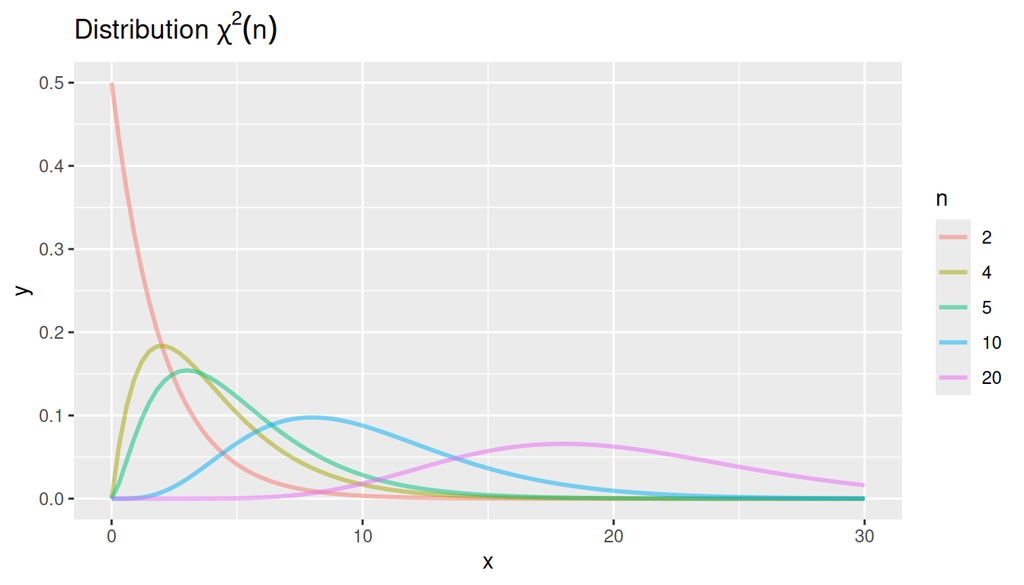

## 4.6 Cas $\mu$ inconnue, échantillons de loi gaussienne

**Note1 - Modélisation supplémentaires**

- Hypothèses gaussienne : $X_i \overset{i.i.d.}{\sim} \mathcal{N}(\mu,\sigma^2)$
- $\mu$ est inconnue.

**Tip3 - Statistique de test et loi sous $H_0$**

Sous $H_0$ :

$$T_n = \frac{(\textcolor{red}{n-1}) S^2}{\sigma_0^2} \sim \chi^2(\textcolor{red}{n-1})$$

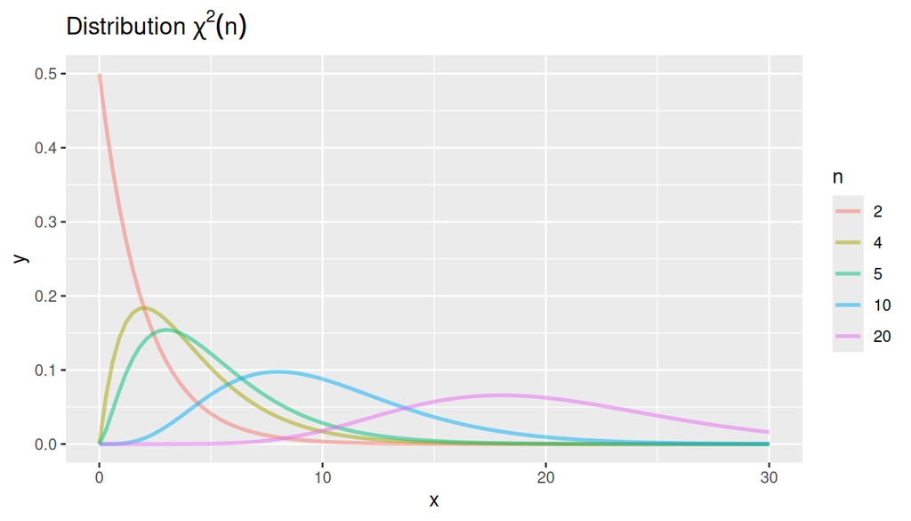

## 4.7 4. Zone de rejet dans le cas gaussien avec $\mu$ inconnu

**Tip4 - Zone de rejet dans le cas bilatéral**

$$R_\alpha = \left]0, \chi^2_{n-1, \frac{\alpha}{2} }\right[ \cup \left]\chi^2_{n-1,1- \frac{\alpha}{2}},+\infty \right[$$

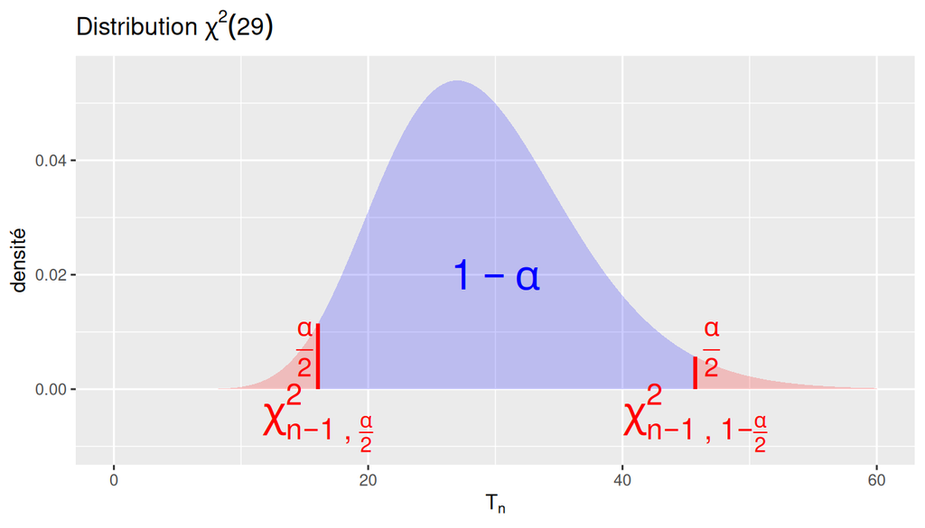

**CautionRemarques**

La zone de rejet n’est pas symétrique !

## 4.8 Exemple sur les jus de fruits

```r
Alpha = 0.05
n=length(x)
var0 = 5**2
var_obs = var(x)
tn = (n-1)*var(x)/var0
print(tn)
```

```
[1] 14.21867
```

```r
print(qchisq(Alpha/2,df=n-1))
```

```
[1] 16.04707
```

```r
print(qchisq(1-Alpha/2,df=n-1))
```

```
[1] 45.72229
```

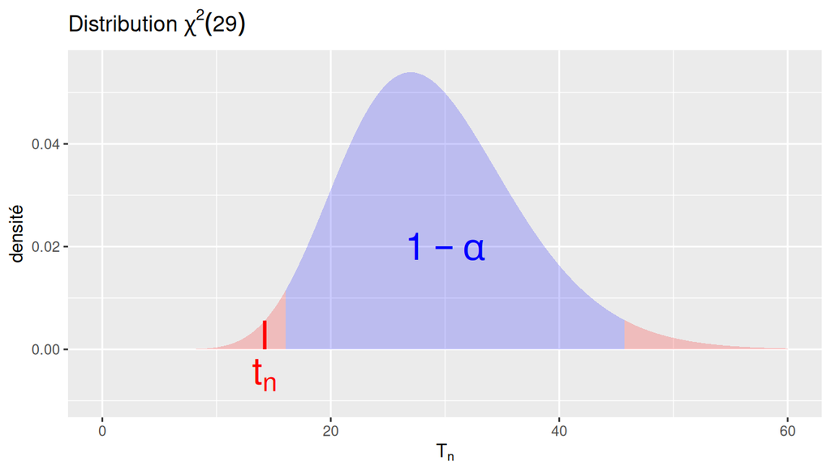

On rejette $H_0$ au niveau $\alpha=5\%$

## 4.9 Cas grand échantillon

Cas $\mu$ **connue**

**Note1 - Modélisation supplémentaire**

- On note $Z_i:=(X_i- \textcolor{blue}{\mu})^2$, de sorte que $\displaystyle S^2 = \frac{1}{n}\sum_{i=1}^nZ_i = \bar{Z}_n$.
- $n>30$
- $\mathbb{E}[X_i^4]$ est finie.

**TipLien avec le test de conformité de moyenne**

**Ce test de conformité de variance est un cas particulier du test de conformité de moyenne**
$$T_n = \sqrt{n}\frac{(S_e^2 - \sigma^2_0)}{\sqrt{\frac{1}{n-1}\sum_{i=1}^n (Z_i - \bar{Z_n})^2}} \sim \mathcal{N}(0,1)$$

Cas $\mu$ **inconnue**

**Note1 - Modélisation supplémentaire**

- On note $W_i:=(X_i- \textcolor{red}{\bar{X_n}})^2$, de sorte que $\displaystyle S^2 = \frac{1}{n-1}\sum_{i=1}^nW_i = \frac{n}{n-1}\bar{W}_n$.
- $n>50$
- $\mathbb{E}[X_i^4]$ est finie.

**TipLien avec le test de conformité de moyenne**

**Ce test de conformité de variance est un cas particulier du test de conformité de moyenne**
$$T_n = \sqrt{n}\frac{(S^2 - \sigma^2_0)}{\sqrt{\frac{1}{n-1}\sum_{i=1}^n (W_i - \bar{W_n})^2}} \sim \mathcal{N}(0,1)$$

## 4.10 Résumé

Table 1: Résumé des lois pour le test de conformité d’une variance

Cas gaussien, $n$ quelconque

|  | Stat. de test | Loi sous $H_0$ |
| --- | --- | --- |
| $\mu$ connue | $T_n = \frac{nS_e^2}{\sigma_0^2}$ | $T_n\sim\chi^2(n)$ |
| $\mu$ inconnue | $T_n = \frac{(n-1)S^2}{\sigma_0^2}$ | $T_n\sim\chi^2(n-1)$ |

Cas non gaussien, $n$ grand

| Stat. de test | Loi sous $H_0$ |
| --- | --- |
| $T_n = \sqrt{n}\frac{(S_e^2 - \sigma^2_0)}{\sqrt{\frac{1}{n-1}\sum_{i=1}^n (Z_i - \bar{Z_n})^2}}$ | $T_n \xrightarrow[n\rightarrow\infty]{\mathscr{L}}\mathcal{N}(0,1)$ |
| $T_n = \sqrt{n}\frac{(S^2 - \sigma^2_0)}{\sqrt{\frac{1}{n-1}\sum_{i=1}^n (W_i - \bar{W_n})^2}}$ | $T_n \xrightarrow[n\rightarrow\infty]{\mathscr{L}}\mathcal{N}(0,1)$ |

**CautionRemarques**

- Les régions de rejet sont définies de la même manière que précédemment en utilisant les quantiles correspondant à la loi de $T_n$ au niveau $\alpha$ fixé.
- Attention les régions de rejet ne sont pas symétriques.

# 5 Conclusion

## 5.1 Ce qu’il faut retenir de ce cours

**Test de conformité d’une proportion**

**TipThéorème : lien avec le test de conformité de moyenne**

**Le test de conformité de proportion est un cas particulier du test de conformité de moyenne**

**Note1 - Modélisation**

$n$-échantillon i.i.d. $(X_1,\dots,X_n)$ de loi $\mathcal{B}(p)$

**Note2 - Hypothèses**

$$H_0 : p=p_0$$

**Tip3 - Statistique de test dans le cas grand échantillon**

$$T_n = \sqrt{n} \frac{(\bar{X}_n-p_0)}{\sqrt{p_0(1-p_0)}}\sim \mathcal{N}(0,1)$$

**Test de conformité d’une variance**

**Note1 - Modélisation**

$n$-échantillon i.i.d. $(X_1,\dots,X_n)$ de loi $\mathcal{N}(\mu,\sigma^2)$

**Note2 - Hypothèses**

$$H_0 : \sigma^2=\sigma^2_0$$

**Tip3 - Statistiques de test**

- $\mu$ est **connue** $S_e^2 = \frac{1}{n}\sum_{i=1}^n (X_i-\mu)^2, \quad T_n = \frac{nS_e^2}{\sigma_0^2} \sim\chi^2(n)$
- $\mu$ est **inconnue** $S^2 = \frac{1}{n-1}\sum_{i=1}^n (X_i-\bar{X}_n)^2,\quad T_n = \frac{(n-1)S^2}{\sigma_0^2} \sim\chi^2(n-1)$

**Tip4 - Zone de rejet dans le cas bilatéral**

$$R_\alpha = \left]0, \chi^2_{n-1, \frac{\alpha}{2} }\right[ \cup \left]\chi^2_{n-1,1- \frac{\alpha}{2}},+\infty \right[$$
La zone de rejet n’est pas symétrique.

## 5.2 Conclusion générale

**Note3 tests de conformité**

- Test de conformité d’une **moyenne**.
- Test de conformité d’une **proportion**.
- Test de conformité d’une **variance**.

**NoteDémarche d’un test**

1. Modélisation des données
2. Hypothèse nulle et hypothèse alternative
3. Choix d’une statistique de test.
4. Déterminer la zone de rejet $R_\alpha$
5. Mise en œuvre du test, application numérique avec R.
6. Calcul de la p-valeur
7. Calcul de la puissance